# STAT 480 Final Project

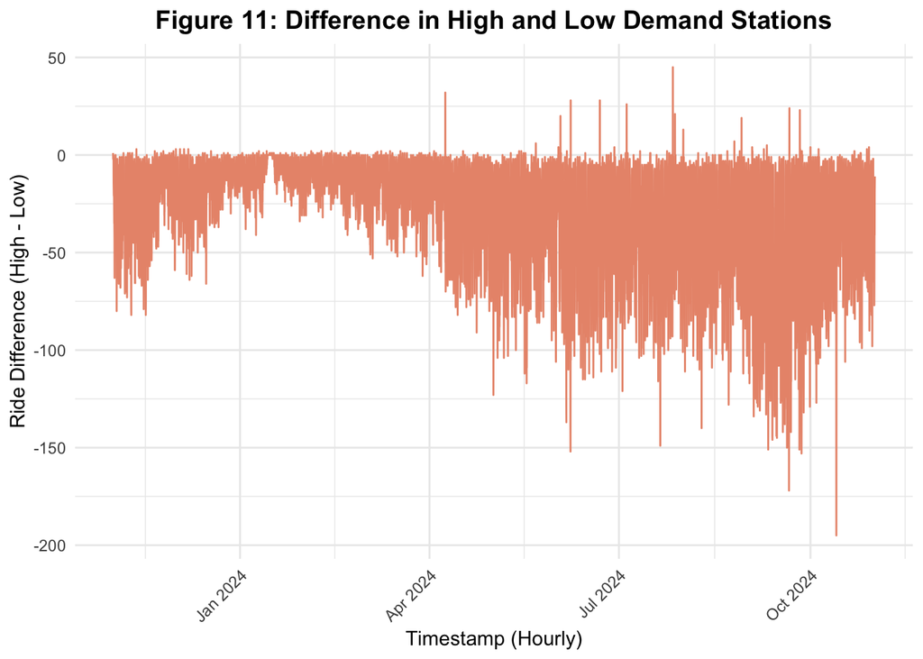

```r
# Line plot for ride difference over time
ggplot(rides_difference, aes(x = timestamp_hour, y = ride_difference)) +
  geom_line(color = "darksalmon") +
  labs(
    title = "Figure 11: Difference in High and Low Demand Stations",
    x = "Timestamp (Hourly)",
    y = "Ride Difference (High - Low)"
  ) +
  theme_minimal() +
  theme(
    axis.text.x = element_text(angle = 45, hjust = 1),
    plot.title = element_text(hjust = 0.5, size = 14, face = "bold")
  )
```

```r
positive_ride_diff <- rides_difference %>%
  filter(ride_difference > 0)
```

```r
# Extract the hour from timestamp_hour
positive_ride_diff <- positive_ride_diff %>%
  mutate(hour = hour(timestamp_hour))

# Count occurrences of each hour
hourly_counts <- positive_ride_diff %>%
  group_by(hour) %>%
  summarize(count = n(), .groups = "drop") %>%
  arrange(desc(count))
```

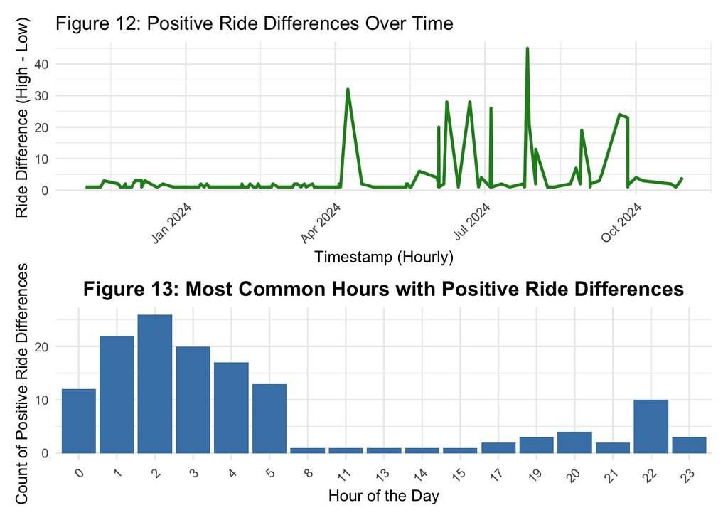

```r
# Figure 12: Positive Ride Differences Over Time
plot_positive_diff <- ggplot(positive_ride_diff, aes(x = timestamp_hour, y = ride_difference)) +
  geom_line(color = "forestgreen", size = 1) +
  labs(
    title = "Figure 12: Positive Ride Differences Over Time",
    x = "Timestamp (Hourly)",
    y = "Ride Difference (High - Low)"
  ) +
  theme_minimal() +
  theme(axis.text.x = element_text(angle = 45, hjust = 1))

# Figure 13: Most Common Hours with Positive Ride Differences
plot_hourly_counts <- ggplot(hourly_counts, aes(x = factor(hour), y = count)) +
  geom_bar(stat = "identity", fill = "steelblue") +
  labs(
    title = "Figure 13: Most Common Hours with Positive Ride Differences",
    x = "Hour of the Day",
    y = "Count of Positive Ride Differences"
  ) +
  theme_minimal() +
  theme(
    plot.title = element_text(hjust = 0.5, size = 14, face = "bold"),
    axis.text.x = element_text(angle = 45, hjust = 1)
  )

# Combine the two plots in a 2x1 layout
combined_plot <- plot_positive_diff / plot_hourly_counts  # Use '/' to stack vertically

# Display the combined plot
combined_plot
```

From Figure 12 and 13 it is clear to see that there are imbalances in high-demand areas during the warmers months in the night time. We can infer that low-demand stations are popular for people to commute for school and work from largely locations in the city outskirts. The flow of rides seems to be balanced in that aspect, however, during warmers months in early mornings and late nights, demand for rides in the downtown areas pick-up despite the relative low “overall rides” during these times as we saw back in Figure 3. It makes sense as the lower overall activity in these times would not encourage a a proper redistribution of vehicles.

As a side note, a time series forecasting model was trialed to fit both the values for high-demand stations and the differences between high-and-low using an ARIMA. We received some decent-enough results, however, the the plot of residuals in the ACF and PACF still indicated a lot of seasonality and cyclical elements that would have required significant tuning to generate more accurate forecasts - which at this point of time is out of the scope of our project.